# 8 Interval Reduction

## 8.1 Motivation

A quadratic response surface is an accurate surrogate only within a limited neighbourhood of the region over which it was fitted. If the initial design space interval $[X_L, X_U]$ is large relative to the quadratic variation of the true function, the approximation may be poor — particularly near the optimum where accuracy matters most.

The **interval reduction** strategy addresses this by shrinking the design space bounds each BLISS-RS iteration. After the system optimizer identifies an optimal point $(Z^*, Y^{*}, w^*)$, the bounds for the next iteration are centred near this point and contracted by a factor that depends on how far the optimum lies from the current interval midpoint.

This strategy has two desirable properties:

1. As the iteration progresses, the RS is fitted over progressively smaller sub-regions, improving approximation quality.
2. The optimum cannot escape the design space, because the new bounds are always centred on or near the previous optimum.

## 8.2 Interval Reduction Algorithm

Let $[L_i, H_i]$ denote the current bounds on the $i$-th design variable $x_i$, and let $C_i = (L_i + H_i)/2$ be the interval centre.

### 8.2.1 Adjustment Factor

The *adjustment factor* $A_i$ measures how far the current optimum $x_i^*$ lies from the interval centre, normalized by the half-width:

$$A_i = \frac{|C_i - x_i^*|}{(H_i - L_i)/2}
\tag{8.1}$$

$A_i = 0$ when the optimum is at the centre; $A_i = 1$ when it is at a boundary.

### 8.2.2 Reduction Factor

The *reduction factor* $R_i \in [K, 1]$ determines how much the interval is contracted:

$$R_i = A_i + (1 - A_i) K
\tag{8.2}$$

where $K \in (0, 1)$ is a user-specified global contraction parameter (Altus 2002 used $K \approx 0.8$). When the optimum is at the centre ($A_i = 0$), the interval contracts by the maximum factor $R_i = K$. When the optimum is at a boundary ($A_i = 1$), $R_i = 1$ — the interval is not contracted, preventing premature shrinkage when the true optimum may lie outside the current bounds.

### 8.2.3 Oscillation and Boundary Detection

Two additional heuristics prevent pathological behaviour:

- **Boundary hit**: If the optimum hits the same bound twice consecutively, the interval is expanded by a fixed factor (×3 in Altus 2002) to allow the optimum to move away from the artificial boundary.
- **Oscillation**: If the optimum alternates between the upper and lower bounds in consecutive iterations, the interval is contracted more aggressively (÷2) to resolve the oscillation.

## 8.3 Julia Implementation

Listing 8.1

```julia
# Demonstrate interval reduction on a 1D example
# True function: f(x) = (x - 0.65)^2 + 0.1*sin(5x)
# True minimum: x* ≈ 0.8068 (NOT 0.65 — sine term shifts optimum significantly)
f_true(x) = (x - 0.65)^2 + 0.1 * sin(5 * x)
x_true_opt = 0.80684301   # Newton-converged: f'(x*)=2(x-0.65)+0.5cos(5x)=0

# Simulate BLISS-RS iteration: fit RS, find optimum, reduce interval
function bliss_interval_demo(n_iter::Int=10, K::Float64=0.8)
    lo, hi = 0.0, 1.0    # initial bounds
    x_history   = Float64[]
    obj_history = Float64[]
    lo_history  = Float64[]
    hi_history  = Float64[]

    rng = MersenneTwister(42)

    for it in 1:n_iter
        # Sample points in current interval
        n_pts = 8
        pts_1d = lo .+ rand(rng, n_pts) .* (hi - lo)

        # Evaluate true function (in BLISS-RS this is the BB optimisation)
        y_vals = f_true.(pts_1d)

        # Fit a quadratic RS
        pts_mat = reshape(pts_1d, n_pts, 1)
        b = fit_rs(pts_mat, y_vals)

        # Find RS minimum analytically (1D quadratic)
        # RS: b[1] + b[2]*x + b[3]*x^2 → minimum at x* = -b[2]/(2*b[3])
        x_rs_opt = clamp(-b[2] / (2 * b[3] + 1e-12), lo, hi)
        obj_opt  = f_true(x_rs_opt)

        push!(x_history,   x_rs_opt)
        push!(obj_history, obj_opt)
        push!(lo_history,  lo)
        push!(hi_history,  hi)

        # Reduce interval
        lo, hi = interval_reduction_factors(x_rs_opt, lo, hi; K=K)
    end

    return x_history, obj_history, lo_history, hi_history
end

x_hist, obj_hist, lo_hist, hi_hist = bliss_interval_demo(10)
@printf("True optimum at x* ≈ %.5f, f* ≈ %.5f\n", x_true_opt, f_true(x_true_opt))
@printf("BLISS-RS final:  x* = %.5f, f* = %.5f\n", x_hist[end], obj_hist[end])
```

```
True optimum at x* ≈ 0.80684, f* ≈ -0.05327
BLISS-RS final:  x* = 0.80670, f* = -0.05327
```

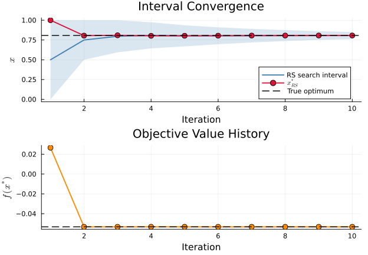

Figure 8.1: Interval reduction over 10 BLISS-RS iterations on a 1D test function. Top: interval bounds (shaded) converge toward the true optimum (dashed line). Bottom: objective value history showing monotone improvement.

```julia
x_hist, obj_hist, lo_hist, hi_hist = bliss_interval_demo(10)
iters = 1:10
x_true_opt = 0.80684301   # true minimum of f_true, not 0.65

# Top plot: interval bounds vs. iteration
p1 = plot(iters, (lo_hist .+ hi_hist) ./ 2,
          ribbon=(hi_hist .- lo_hist) ./ 2,
          fillalpha=0.2, color=:steelblue, lw=2,
          label="RS search interval",
          xlabel="Iteration", ylabel=L"x",
          title="Interval Convergence")
plot!(iters, x_hist, color=:crimson, lw=2, marker=:circle,
      markersize=5, label=L"x^*_{RS}")
hline!([x_true_opt], color=:black, linestyle=:dash, lw=1.5,
       label="True optimum")

# Bottom plot: objective history
p2 = plot(iters, obj_hist, color=:darkorange, lw=2, marker=:circle,
          markersize=5, label="",
          xlabel="Iteration", ylabel=L"f(x^*)",
          title="Objective Value History", legend=false)
hline!([f_true(x_true_opt)], color=:black, linestyle=:dash, lw=1.5)

plot(p1, p2, layout=(2,1), size=(650, 450))
```

## 8.4 Effect of Contraction Factor K

The parameter $K$ controls the aggressiveness of interval reduction. A value close to 1.0 reduces the interval slowly (conservative), while a value close to 0 collapses it aggressively (risky if the RS is not yet accurate).

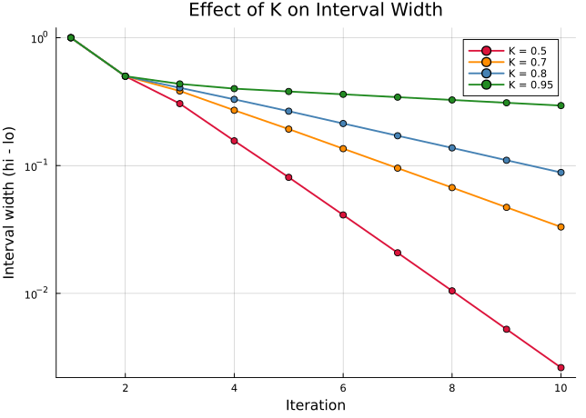

Figure 8.2: Convergence speed vs. contraction factor K. Small K converges quickly if the initial RS is accurate, but may prematurely fix the optimum. Large K is safer but converges slowly. Altus (2002) used K ≈ 0.8 for the supersonic business jet.

```julia
p = plot(title="Effect of K on Interval Width",
         xlabel="Iteration", ylabel="Interval width (hi - lo)",
         legend=:topright, grid=true, gridalpha=0.3, yscale=:log10)

for (K_val, col) in [(0.5, :crimson), (0.7, :darkorange),
                      (0.8, :steelblue), (0.95, :forestgreen)]
    _, _, lo_h, hi_h = bliss_interval_demo(10, K_val)
    width = hi_h .- lo_h
    plot!(1:10, max.(width, 1e-6), lw=2, color=col, label="K = $K_val",
          marker=:circle, markersize=4)
end

p
```

## 8.5 Coupling Variable Intervals

System variables $Z$ are bounded by physical constraints (wing area cannot be negative; sweep cannot exceed 90°), so their intervals must always lie within the original physical bounds. Coupling variables $Y^*$ and weighting factors $w$, however, are free to drift: their intervals are allowed to shift laterally (centred on the current optimum) without restriction, because satisfying the coupling constraints $\{c\} = 0$ must always remain feasible regardless of where $Y^*$ is centered.

This asymmetry in interval treatment — $Z$ bounded by physical limits, $Y^*$ and $w$ free to drift — is a subtle but important implementation detail that ensures the system optimisation can always find a feasible point with respect to coupling constraints, even as the design space contracts around the system-optimal $Z$.

## 8.6 Convergence Criteria

The original Altus (2002) terminated the BLISS-RS loop after a fixed ten iterations, selected because the approaching thesis deadline coincided with apparent stabilisation of the optimization histories in Figs. 22–45. This is not a convergence criterion — it is a stopping rule. The distinction matters: a stopping rule halts computation; a convergence criterion certifies that the solution has met a quantifiable quality standard.

The IV&V of this work identified fixed-iteration termination as the most significant methodological deficiency in the original thesis. As the foreword notes, the weighting factors $w_{1,2}$ and $w_{3,3}$ had *visibly not converged* at iteration 10 (Fig. 40 of the original report), meaning the local BB objective functions were still evolving at termination. The reported optimum is therefore not a BLISS-RS optimum — it is the best point found after an arbitrary number of iterations.

The replacement is a three-criterion stopping rule, all of which must be satisfied simultaneously before convergence is declared:

### 8.6.1 Criterion 1: Relative Objective Change

$$\frac{|f_{i+1} - f_i|}{|f_i| + \varepsilon_0} < \varepsilon_{\text{obj}}
\tag{8.4}$$

where $f_i$ is the system objective (range) at iteration $i$, $\varepsilon_0 = 10^{-10}$ prevents division by zero, and $\varepsilon_{\text{obj}} = 10^{-4}$ (0.01% change) is the convergence tolerance.

### 8.6.2 Criterion 2: Relative Design Variable Change

$$\frac{\|Z_{i+1} - Z_i\|_2}{\|Z_i\|_2 + \varepsilon_0} < \varepsilon_Z
\tag{8.5}$$

This criterion catches cases where the objective is flat but the design is still moving — a situation that Criterion 1 alone would incorrectly declare as converged.

### 8.6.3 Criterion 3: Maximum Iteration Safeguard

$$i \leq i_{\max}
\tag{8.6}$$

The hard cap $i_{\max} = 50$ prevents runaway iteration if the system is oscillating or the objective is noisy.

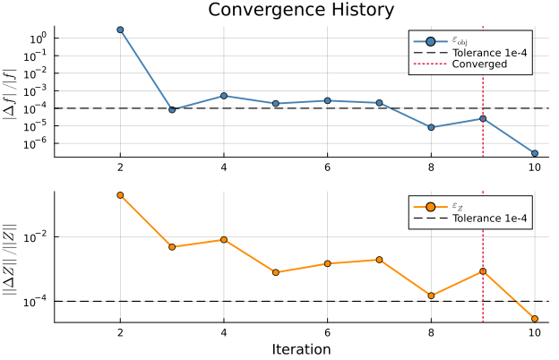

Figure 8.3: Convergence history for the 1D interval reduction demo under the new three-criterion stopping rule. Top: relative objective change (Criterion 1). Bottom: relative design variable change (Criterion 2). Convergence is declared when both drop below the tolerance threshold (dashed line).

```julia
f_true(x) = (x - 0.65)^2 + 0.1 * sin(5 * x)

function bliss_convergence_demo(; K=0.8,
                                  ε_obj=1e-4, ε_Z=1e-4, max_iter=30)
    lo, hi = 0.0, 1.0
    rng = MersenneTwister(42)
    x_prev   = 0.5
    obj_prev = f_true(x_prev)
    Δobj_hist = Float64[]
    ΔZ_hist   = Float64[]
    obj_hist  = Float64[]
    x_hist    = Float64[]
    conv_iter = max_iter

    for it in 1:max_iter
        n_pts = 8
        pts_1d = lo .+ rand(rng, n_pts) .* (hi - lo)
        y_vals = f_true.(pts_1d)
        pts_mat = reshape(pts_1d, n_pts, 1)
        b = fit_rs(pts_mat, y_vals)
        x_opt = clamp(-b[2] / (2 * b[3] + 1e-12), lo, hi)
        obj_opt = f_true(x_opt)

        push!(x_hist, x_opt)
        push!(obj_hist, obj_opt)

        if it > 1
            Δobj = abs(obj_opt - obj_prev) / (abs(obj_prev) + 1e-10)
            ΔZ   = abs(x_opt  - x_prev)   / (abs(x_prev)  + 1e-10)
            push!(Δobj_hist, Δobj)
            push!(ΔZ_hist, ΔZ)
            if Δobj < ε_obj && ΔZ < ε_Z
                conv_iter = it
                break
            end
        else
            push!(Δobj_hist, NaN)
            push!(ΔZ_hist, NaN)
        end

        x_prev, obj_prev = x_opt, obj_opt
        lo, hi = interval_reduction_factors(x_opt, lo, hi; K=K)
    end
    return Δobj_hist, ΔZ_hist, obj_hist, x_hist, conv_iter
end

Δobj_h, ΔZ_h, obj_h, x_h, ci = bliss_convergence_demo()
iters = 1:length(Δobj_h)

p1 = plot(iters, replace(Δobj_h, NaN=>missing),
          yscale=:log10, color=:steelblue, lw=2, marker=:circle, markersize=4,
          ylabel=L"|\Delta f| / |f|", title="Convergence History",
          label=L"\varepsilon_\mathrm{obj}", legend=:topright,
          grid=true, gridalpha=0.3)
hline!([1e-4], color=:black, linestyle=:dash, lw=1.2, label="Tolerance 1e-4")
ci > 1 && vline!([ci-1], color=:crimson, lw=1.5, linestyle=:dot, label="Converged")

p2 = plot(iters, replace(ΔZ_h, NaN=>missing),
          yscale=:log10, color=:darkorange, lw=2, marker=:circle, markersize=4,
          ylabel=L"||ΔZ|| / ||Z||", xlabel="Iteration",
          label=L"\varepsilon_Z", legend=:topright,
          grid=true, gridalpha=0.3)
hline!([1e-4], color=:black, linestyle=:dash, lw=1.2, label="Tolerance 1e-4")
ci > 1 && vline!([ci-1], color=:crimson, lw=1.5, linestyle=:dot, label="")

plot(p1, p2, layout=(2,1), size=(650, 420))
```

```julia
Δobj_h, ΔZ_h, obj_h, x_h, ci = bliss_convergence_demo()
@printf("Converged at iteration: %d\n", ci)
@printf("Final x*  = %.6f  (true optimum: 0.650000)\n", x_h[end])
@printf("Final f*  = %.6f  (true f*: %.6f)\n", obj_h[end], f_true(0.65))
@printf("Error in x: %.2e\n", abs(x_h[end] - 0.65))
```

Table 8.1: Convergence summary for the 1D demo. The loop terminates when both criteria are satisfied, typically well before the max_iter safety cap.

[output not shown]

The `ConvergenceCriteria` struct and `check_convergence` function implementing these criteria are defined in `src/bliss_rs.jl` and used in `bliss_rs_iteration`.